# Score-Intensity Visualization for FT-ICR-MS data

N Green

2015-12-03

### Install packages. Skip if already done.

```r
install.packages("hexbin")
install.packages("dplyr")
install.packages("plotrix")
```

### Import data with read.csv

```r
scint <- read.csv("../data/scint.csv")
```

### Filter out data outside plotting range

```r
scint3<-scint %>% filter(O.C<=1&H.C<=2.25)
```

### To know what percent of intensity is outside plotting range.

```r
dif.t<-sum(scint$scINT)-sum(scint3$scINT)
dif.p<-100*dif.t/sum(scint$scINT)
dif.p
```

```
## [1] NaN
```

### Begin creating the hexagonal bin plot. Function to create colormap – can paste and run at once

```r
myColorRamp <- function(colors, values) {
v <- (values - min(values))/diff(range(values))
x <- colorRamp(colors)(v)
rgb(x[,1], x[,2], x[,3], maxColorValue = 255)
}
```

### This generates the bins. xbins is the number across, and can be changed (larger is more bins)

```r
hbin<-hexbin(scint3$O.C, scint3$H.C, xbins=40, IDs=TRUE)
```

### Calculate the intensity sums based on the bins

```r
SumHexBin<-data.frame(sums=hexTapply(hbin,scint3$ScINT,sum))
```

### Generate the colors for each hexagon

```r
cols<-myColorRamp(c("white","green","yellow","red"),SumHexBin$sums)
```

### Build the plot

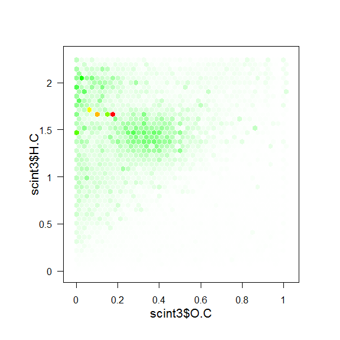

```r
P <- plot(hbin, type="n",legend=FALSE)
pushHexport(P$plot.vp)
grid.hexagons(hbin, style= "lattice", border = gray(1), pen = cols,  minarea = 1, maxarea = 1)
```

### Finishing touches of plots done in Inkscape, a free vector graphics program. Plots were exported in svg format from RStudio.

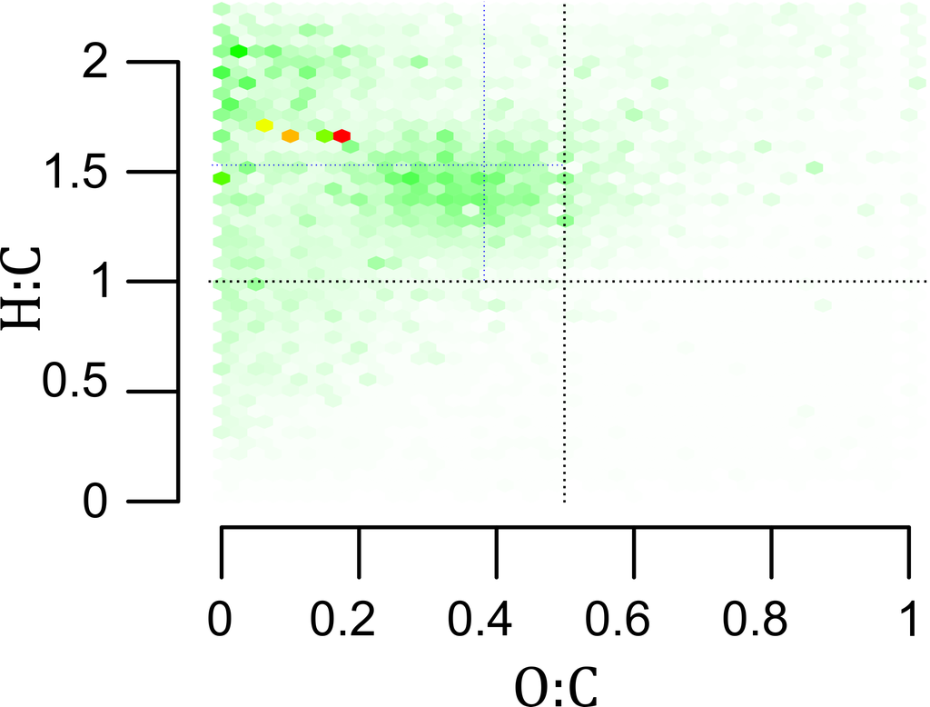

# END of current file

Still to be added are direct calculation of Score-intensity from output file and additional plotting. While I like this hexplot it would be nice to do a similar thing in ggplot.

### Import fit file and skip header and certain columns and filter out rank zero

s10063 <- read.table(“C:/Users/NWG_Laptop/Desktop/00.org.doc/project/scint/GSF-2008/s10063.fit”, quote=“"”, comment.char=“”,skip = 64,colClasses = c(“integer”,rep(“NULL”,3),“numeric”,rep(“NULL”,3),rep(“integer”,4),rep(“NULL”,6),rep(“integer”,2))) library(dplyr) s100633<-s10063 %>% filter(V20>0) dif.t<-sum(s10063$V5) dif.f<-sum(s100633$V5) dif.p<-100*dif.f/dif.t

### Creating the secondary data frame

tscint<-data.frame(O.C=(s100633$V12 / (s100633$V9 + s100633$V10))) tscint$H.C<-s100633$V11 / (s100633$V9 + s100633$V10) tscint$scINT<-(s100633$V5*s100633$V19)/(ave(ave(s100633$V19,s100633$V1,FUN=cumsum),interaction(s100633$V1,drop=T),FUN=max,na.rm=T)) tscint3<-tscint %>% filter(O.C<=1&H.C<=2.25) dif.tot<-sum(tscint$scINT)-sum(tscint3$scINT) dif.per<-100*dif.t/sum(tscint$scINT) dif.per<-100*dif.tot/sum(tscint$scINT) thbin<-hexbin(tscint3$O.C, tscint3$H.C, xbins=40, IDs=TRUE) tSumHexBin<-data.frame(sums=hexTapply(thbin,tscint3$scINT,sum)) tcols<-myColorRamp(c(“white”,“green”,“yellow”,“red”),tSumHexBin$sums) tP <- plot(thbin, type="n",legend=FALSE) pushHexport(tP$plot.vp) grid.hexagons(thbin, style= “lattice”, border = gray(1), pen = tcols, minarea = 1, maxarea = 1)

### gridder.R function and some ggplot examples

gridded.data<-gridder(scint3$O.C,scint3$H.C,scint3$ScINT,seq(0,1.5,0.05),seq(0,2.25,0.05)) names(gridded.data) <- c(“O.C”,“H.C”,“scINT”) library(ggplot2) g <- ggplot(gridded.data,aes(x=O.C,y=H.C,z=scINT)) g + stat_contour() g + stat_contour() g + stat_summary2d() g <- ggplot(scint3,aes(x=O.C,y=H.C,z=scINT)) g + stat_summary2d()